# Reproducible Research, assignment week 2

P.A. de Roos

February 7, 2017

Set the working directory & load the dataset.

```r
setwd("C:/Users/paul/OneDrive/Coursera/Reproducible Research")
Activity <- read.csv("activity.csv")
head(Activity)
```

```
##   steps       date interval
## 1    NA 2012-10-01        0
## 2    NA 2012-10-01        5
## 3    NA 2012-10-01       10
## 4    NA 2012-10-01       15
## 5    NA 2012-10-01       20
## 6    NA 2012-10-01       25
```

Calculate the number of steps per day and display as histogram.

```r
(StepsPerDay <- with(Activity, tapply(steps, date, sum)))
```

```
## 2012-10-01 2012-10-02 2012-10-03 2012-10-04 2012-10-05 2012-10-06
##         NA        126      11352      12116      13294      15420
## 2012-10-07 2012-10-08 2012-10-09 2012-10-10 2012-10-11 2012-10-12
##      11015         NA      12811       9900      10304      17382
## 2012-10-13 2012-10-14 2012-10-15 2012-10-16 2012-10-17 2012-10-18
##      12426      15098      10139      15084      13452      10056
## 2012-10-19 2012-10-20 2012-10-21 2012-10-22 2012-10-23 2012-10-24
##      11829      10395       8821      13460       8918       8355
## 2012-10-25 2012-10-26 2012-10-27 2012-10-28 2012-10-29 2012-10-30
##       2492       6778      10119      11458       5018       9819
## 2012-10-31 2012-11-01 2012-11-02 2012-11-03 2012-11-04 2012-11-05
##      15414         NA      10600      10571         NA      10439
## 2012-11-06 2012-11-07 2012-11-08 2012-11-09 2012-11-10 2012-11-11
##       8334      12883       3219         NA         NA      12608
## 2012-11-12 2012-11-13 2012-11-14 2012-11-15 2012-11-16 2012-11-17
##      10765       7336         NA         41       5441      14339
## 2012-11-18 2012-11-19 2012-11-20 2012-11-21 2012-11-22 2012-11-23
##      15110       8841       4472      12787      20427      21194
## 2012-11-24 2012-11-25 2012-11-26 2012-11-27 2012-11-28 2012-11-29
##      14478      11834      11162      13646      10183       7047
## 2012-11-30
##         NA
```

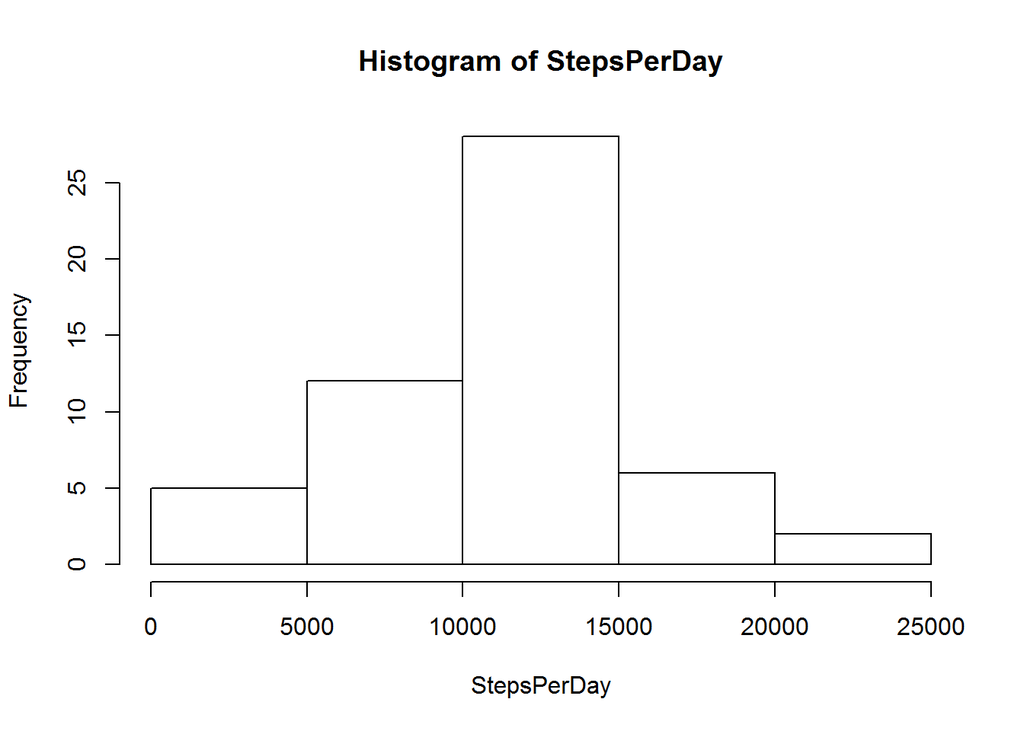

```r
hist(StepsPerDay)
```

Calculate the mean and median of the total number of steps per day.

```r
(MeanStepsPerDay <- mean(StepsPerDay, na.rm = T))
```

```
## [1] 10766.19
```

```r
(MedianStepsPerDay <- median(StepsPerDay, na.rm = T))
```

```
## [1] 10765
```

Create a time series plot of average steps per time of day.

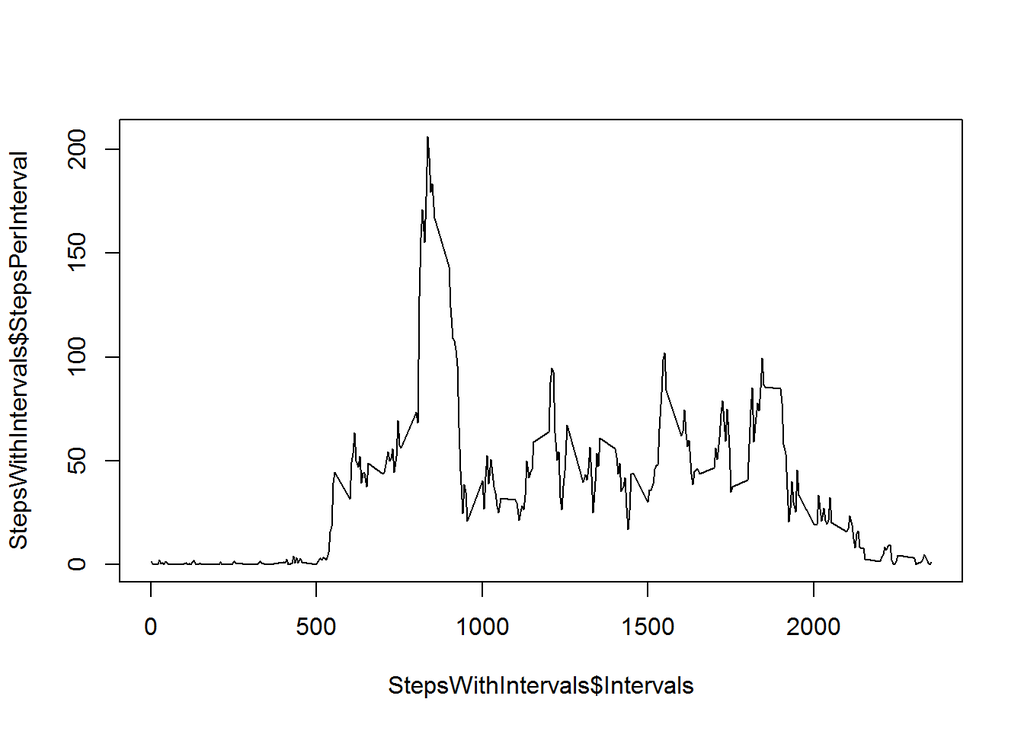

```r
StepsPerInterval <- with(Activity, tapply(steps, interval, mean, na.rm = T))
Intervals <- sort(unique(Activity$interval), decreasing = F)
StepsWithIntervals <- as.data.frame(cbind(Intervals, StepsPerInterval))
plot.ts(x=StepsWithIntervals$Intervals, y= StepsWithIntervals$StepsPerInterval, type="l")
```

Calculate the interval which has the highest amount of steps.

```r
(HighestSteps <- StepsWithIntervals[which(StepsWithIntervals$StepsPerInterval == max(StepsWithIntervals$StepsPerInterval)),])
```

```
##     Intervals StepsPerInterval
## 835       835         206.1698
```

Count the number of days with NA values (note these dates may also have non-NA values).

```r
length(unique(Activity$date[is.na(Activity$steps)]))
```

```
## [1] 8
```

Fill the NA values with the average steps per interval, step 1: create a new dataset without NA’s.

```r
Activity2 <- Activity[!is.na(Activity),]
```

Fill the NA values with the average steps per interval, step 2: calculate the average number of steps per interval.

```r
MeanStepsPerInterval <- aggregate(Activity2$steps, list(Activity2$interval), mean, na.action = na.omit)
(colnames(MeanStepsPerInterval) <- c("interval", "meanSteps"))
```

```
## [1] "interval"  "meanSteps"
```

Fill the NA values with the average steps per interval, step 3: merge the avg. no. of steps per interval with a copy of the original dataset.

```r
library(data.table)
Activity3 <- Activity
Activity3 <- merge(Activity, MeanStepsPerInterval)
head(Activity3)
```

```
##   interval steps       date meanSteps
## 1        0    NA 2012-10-01  1.716981
## 2        0     0 2012-11-23  1.716981
## 3        0     0 2012-10-28  1.716981
## 4        0     0 2012-11-06  1.716981
## 5        0     0 2012-11-24  1.716981
## 6        0     0 2012-11-15  1.716981
```

Fill the NA values with the average steps per interval, step 4: replace the NA’s with the averages, then lose the meanSteps column.

```r
Activity3$steps <- ifelse(!is.na(Activity3$steps) , Activity3$steps, Activity3$meanSteps)
Activity3 <- Activity3[-4]
head(Activity3)
```

```
##   interval    steps       date
## 1        0 1.716981 2012-10-01
## 2        0 0.000000 2012-11-23
## 3        0 0.000000 2012-10-28
## 4        0 0.000000 2012-11-06
## 5        0 0.000000 2012-11-24
## 6        0 0.000000 2012-11-15
```

Calculate the number of steps per day -based on the dataset with imputed values- and display as histogram.

```r
(StepsPerDay_withImputedValues <- with(Activity3, tapply(steps, date, sum)))
```

```
## 2012-10-01 2012-10-02 2012-10-03 2012-10-04 2012-10-05 2012-10-06
##   10766.19     126.00   11352.00   12116.00   13294.00   15420.00
## 2012-10-07 2012-10-08 2012-10-09 2012-10-10 2012-10-11 2012-10-12
##   11015.00   10766.19   12811.00    9900.00   10304.00   17382.00
## 2012-10-13 2012-10-14 2012-10-15 2012-10-16 2012-10-17 2012-10-18
##   12426.00   15098.00   10139.00   15084.00   13452.00   10056.00
## 2012-10-19 2012-10-20 2012-10-21 2012-10-22 2012-10-23 2012-10-24
##   11829.00   10395.00    8821.00   13460.00    8918.00    8355.00
## 2012-10-25 2012-10-26 2012-10-27 2012-10-28 2012-10-29 2012-10-30
##    2492.00    6778.00   10119.00   11458.00    5018.00    9819.00
## 2012-10-31 2012-11-01 2012-11-02 2012-11-03 2012-11-04 2012-11-05
##   15414.00   10766.19   10600.00   10571.00   10766.19   10439.00
## 2012-11-06 2012-11-07 2012-11-08 2012-11-09 2012-11-10 2012-11-11
##    8334.00   12883.00    3219.00   10766.19   10766.19   12608.00
## 2012-11-12 2012-11-13 2012-11-14 2012-11-15 2012-11-16 2012-11-17
##   10765.00    7336.00   10766.19      41.00    5441.00   14339.00
## 2012-11-18 2012-11-19 2012-11-20 2012-11-21 2012-11-22 2012-11-23
##   15110.00    8841.00    4472.00   12787.00   20427.00   21194.00
## 2012-11-24 2012-11-25 2012-11-26 2012-11-27 2012-11-28 2012-11-29
##   14478.00   11834.00   11162.00   13646.00   10183.00    7047.00
## 2012-11-30
##   10766.19
```

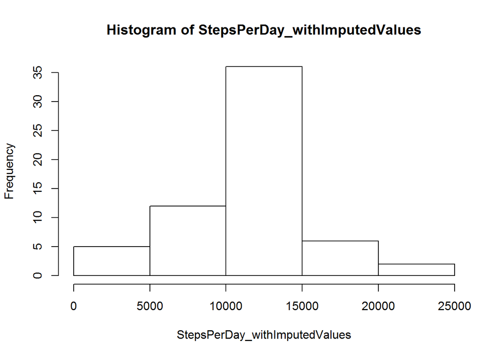

```r
hist(StepsPerDay_withImputedValues)
```

Calculate the mean and median of the total number of steps per day -based on the dataset with imputed values-.

```r
(MeanStepsPerDay_withImputedValues <- mean(StepsPerDay_withImputedValues, na.rm = T))
```

```
## [1] 10766.19
```

```r
(MedianStepsPerDay_withImputedValues <- median(StepsPerDay_withImputedValues, na.rm = T))
```

```
## [1] 10766.19
```

Create a new factor variable (weekday/weekend).

```r
weekdayOrWeekend <- as.factor(weekdays(as.Date(Activity3$date)))
weekdayOrWeekend <- ifelse(weekdayOrWeekend=="Saturday"|weekdayOrWeekend=="Sunday", "Weekend", "Weekday")
Activity_WoW <- cbind(Activity3, weekdayOrWeekend)
head(Activity_WoW)
```

```
##   interval    steps       date weekdayOrWeekend
## 1        0 1.716981 2012-10-01          Weekday
## 2        0 0.000000 2012-11-23          Weekday
## 3        0 0.000000 2012-10-28          Weekend
## 4        0 0.000000 2012-11-06          Weekday
## 5        0 0.000000 2012-11-24          Weekend
## 6        0 0.000000 2012-11-15          Weekday
```

```r
StepsPerInterval_WoW <- with(Activity_WoW, tapply(steps, interval, mean, na.rm = T))
Intervals_WoW <- sort(unique(Activity_WoW$interval), decreasing = F)
StepsWithIntervals_WoW <- as.data.frame(cbind(Intervals_WoW, StepsPerInterval_WoW))
```

Step 2: Split the dataset in 2 dataset and plot them both.

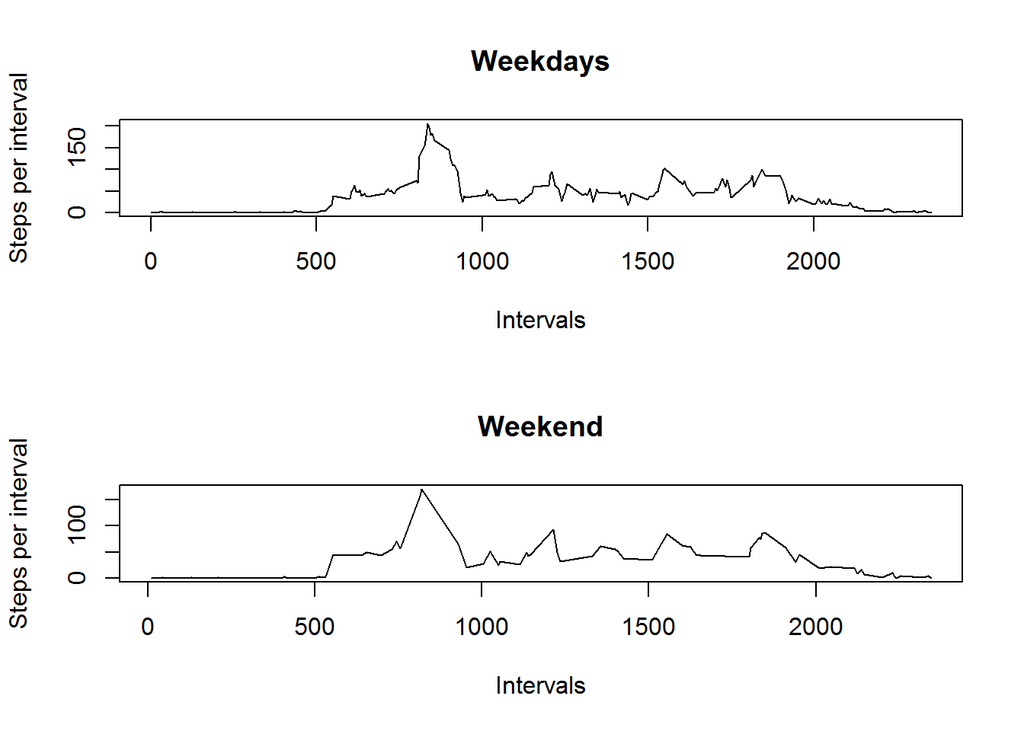

```r
Weekday <- StepsWithIntervals_WoW[weekdayOrWeekend =="Weekday",]
Weekend <- StepsWithIntervals_WoW[weekdayOrWeekend =="Weekend",]
par(mfrow=c(2,1))
plot.ts(x=Weekday$Intervals, y= Weekday$StepsPerInterval, type="l", main="Weekdays", xlab="Intervals", ylab="Steps per interval")
plot.ts(x=Weekend$Intervals, y= Weekend$StepsPerInterval, type="l", main="Weekend", xlab="Intervals", ylab="Steps per interval")
```